# Week 7 Practice

BDS

July 3, 2018

```r
library(dplyr)

library(psych)

library(mice)
```

Data comes in all wacky forms – you will often find that data vendors hold their data with some odd delimiter. If we take a look at our first line of data, we can see that some weird things are happening:

```r
readLines("C://Users/berry2006/Documents/projects/courses/bds/exerciseData/week07.txt")[1:10]
```

```
##  [1] "\"id\"|\"team\"|\"manager\"|\"jobTasksSDSA\"|\"jobBalanceSDSA\"|\"jobPaySDSA\"|\"jobRecognitionSDSA\"|\"jobAdvancementSDSA\"|\"jobCoworkersSDSA\"|\"jobManagementSDSA\"|\"salary\"|\"tenure\""
##  [2] "\"1\"|\"\"|\"\"|\"\"|\"\"|\"\"|\"\"|\"\"|\"\"|\"\"|\"\"|\"\"|\"\""
##  [3] "\"2\"|\"W472V\"|\"Ethics\"|\"X8022Z\"|\"7\"|\"3\"|\"7\"|\"7\"|\"7\"|\"5\"|\"4\"|\"126460\"|\"6\""
##  [4] "\"3\"|\"S227N\"|\"DSI\"|\"V8472W\"|\"1\"|\"6\"|\"3\"|\"2\"|\"2\"|\"7\"|\"7\"|\"47749\"|\"1\""
##  [5] "\"4\"|\"N333E\"|\"Finance\"|\"X7645X\"|\"7\"|\"7\"|\"7\"|\"7\"|\"7\"|\"7\"|NA|\"80828\"|\"6\""
##  [6] "\"5\"|\"K503P\"|\"Finance\"|\"Y4468Y\"|\"2\"|\"2\"|\"4\"|\"3\"|\"4\"|\"3\"|\"3\"|\"52852\"|\"6\""
##  [7] "\"6\"|\"J845U\"|\"R&D\"|\"X8066X\"|\"6\"|\"3\"|\"7\"|\"7\"|\"7\"|\"4\"|\"4\"|\"98429\"|\"10\""
##  [8] "\"7\"|\"O834K\"|\"Finance\"|\"Z7298V\"|\"3\"|\"3\"|\"4\"|\"4\"|\"4\"|\"4\"|\"3\"|\"45397\"|\"1\""
##  [9] "\"8\"|\"S167E\"|\"R&D\"|\"Z2464Y\"|\"2\"|\"3\"|\"3\"|\"4\"|\"3\"|\"4\"|\"5\"|\"171648\"|\"8\""
## [10] "\"9\"|\"M198N\"|\"R&D\"|\"X3607X\"|\"7\"|\"4\"|\"7\"|\"7\"|\"7\"|\"5\"|\"6\"|\"53330\"|\"7\""
```

A pipe…not a tidyverse pipe, but an actual pipe. Incredible! You would be shocked at the delimiters you will see in the wild.

It won’t take too much to make this happen:

```r
week7 = read.delim("C://Users/berry2006/Documents/projects/courses/bds/exerciseData/week07.txt", header = TRUE, sep = "|")

head(week7)
```

```
##      id    team manager jobTasksSDSA jobBalanceSDSA jobPaySDSA
## 1                                 NA             NA         NA
## 2 W472V  Ethics  X8022Z            7              3          7
## 3 S227N     DSI  V8472W            1              6          3
## 4 N333E Finance  X7645X            7              7          7
## 5 K503P Finance  Y4468Y            2              2          4
## 6 J845U     R&D  X8066X            6              3          7
##   jobRecognitionSDSA jobAdvancementSDSA jobCoworkersSDSA jobManagementSDSA
## 1                 NA                 NA               NA                NA
## 2                  7                  7                5                 4
## 3                  2                  2                7                 7
## 4                  7                  7                7                NA
## 5                  3                  4                3                 3
## 6                  7                  7                4                 4
##   salary tenure
## 1     NA     NA
## 2 126460      6
## 3  47749      1
## 4  80828      6
## 5  52852      6
## 6  98429     10
```

When we look at the first few rows, we see that we have a blank first row (also far too common in the wild).

We have some options here. If this was a large data frame and the read time was long, I would just drop the index with something like this:

```r
week7 = week7[-1, ]
```

The use of magic numbers, though, is a bit dangerous and we probably should not engage in such risky business.

```r
week7Names = read.table("C://Users/berry2006/Documents/projects/courses/bds/exerciseData/week07.txt", header = TRUE, sep = "|", nrows = 1)

week7 = read.table("C://Users/berry2006/Documents/projects/courses/bds/exerciseData/week07.txt", header = TRUE, sep = "|", skip = 1, row.names = 1)

names(week7) = names(week7Names)
```

That is a lot of steps, but we don’t always need to worry about code golf. This solution will work under many different situations and is a trick that you should keep with you – you never know when you might want to use it.

Let’s check out our data now:

```r
summary(week7)
```

```
##        id            team        manager     jobTasksSDSA
##  A103R  :   1   DSI    : 64   Y9641W : 99   Min.   :1.000
##  A105D  :   1   Ethics :199   X7645X : 95   1st Qu.:2.000
##  A105O  :   1   Finance:441   Y3553W : 95   Median :4.000
##  A126C  :   1   Health :239   Y4468Y : 91   Mean   :4.004
##  A129A  :   1   R&D    :441   X8066X : 88   3rd Qu.:6.000
##  A163W  :   1                 Z2464Y : 88   Max.   :7.000
##  (Other):1378                 (Other):828
##  jobBalanceSDSA    jobPaySDSA    jobRecognitionSDSA jobAdvancementSDSA
##  Min.   :1.000   Min.   :1.000   Min.   :1.000      Min.   :1.00
##  1st Qu.:2.000   1st Qu.:4.000   1st Qu.:4.000      1st Qu.:4.00
##  Median :4.000   Median :6.000   Median :5.000      Median :5.00
##  Mean   :4.069   Mean   :5.178   Mean   :5.173      Mean   :5.21
##  3rd Qu.:6.000   3rd Qu.:7.000   3rd Qu.:7.000      3rd Qu.:7.00
##  Max.   :7.000   Max.   :7.000   Max.   :7.000      Max.   :7.00
##
##  jobCoworkersSDSA jobManagementSDSA     salary           tenure
##  Min.   :1.000    Min.   :0.000     Min.   : 45002   Min.   : 0.000
##  1st Qu.:4.000    1st Qu.:4.000     1st Qu.: 53555   1st Qu.: 2.000
##  Median :6.000    Median :5.000     Median : 64990   Median : 5.000
##  Mean   :5.259    Mean   :5.174     Mean   : 76578   Mean   : 4.952
##  3rd Qu.:7.000    3rd Qu.:7.000     3rd Qu.: 93051   3rd Qu.: 8.000
##  Max.   :7.000    Max.   :7.000     Max.   :171648   Max.   :10.000
##                   NA's   :212
```

Largely great. During the last few weeks, we have noticed that there is some missingness within our data. With those 212 missing responses on jobManagementSDSA, we are cutting our sample by roughly 15% for any analyses that we might run. I would say that is significant, but not even close to what you might see in other data.

Let’s get a baseline model working:

```r
week7FA = week7 %>%
  select(starts_with("job")) %>%
  fa(., nfactors = 2, rotate = "promax")

week7 = week7 %>%
  mutate(jobScore = week7FA$scores[, "MR1"],
         interpersonalScore = week7FA$scores[, "MR2"])
```

Nothing new there from the last few weeks, so let’s test out some models:

```r
missingSlim = lm(jobScore ~ salary, data = week7)

summary(missingSlim)
```

```
##
## Call:
## lm(formula = jobScore ~ salary, data = week7)
##
## Residuals:
##     Min      1Q  Median      3Q     Max
## -1.7415 -0.9405  0.0461  1.0104  1.3472
##
## Coefficients:
##               Estimate Std. Error t value Pr(>|t|)
## (Intercept) -1.278e-01  7.706e-02  -1.658   0.0975 .
## salary       2.372e-07  9.290e-07   0.255   0.7985
## ---
## Signif. codes:  0 '***' 0.001 '**' 0.01 '*' 0.05 '.' 0.1 ' ' 1
##
## Residual standard error: 0.9946 on 1170 degrees of freedom
##   (212 observations deleted due to missingness)
## Multiple R-squared:  5.572e-05,  Adjusted R-squared:  -0.0007989
## F-statistic: 0.06519 on 1 and 1170 DF,  p-value: 0.7985
```

Again, we have already seen this stuff before. We know, though, that we have some missing data in these models. With that, we need to do something about it.

Let’s try to impute the missing values for jobScore. The mice function allows some pretty slick action to happen when setting the iterations to 0 – it gives you the ability to hack into the object and use it for the actual model!

```r
baseInfo = mice(week7, maxit = 0)

baseInfo$method
```

```
##                 id               team            manager
##                 ""                 ""                 ""
##       jobTasksSDSA     jobBalanceSDSA         jobPaySDSA
##                 ""                 ""                 ""
## jobRecognitionSDSA jobAdvancementSDSA   jobCoworkersSDSA
##                 ""                 ""                 ""
##  jobManagementSDSA             salary             tenure
##              "pmm"                 ""                 ""
##           jobScore interpersonalScore
##              "pmm"              "pmm"
```

```r
baseInfo$predictorMatrix
```

```
##                    id team manager jobTasksSDSA jobBalanceSDSA jobPaySDSA
## id                  0    1       1            1              1          1
## team                1    0       1            1              1          1
## manager             1    1       0            1              1          1
## jobTasksSDSA        1    1       1            0              1          1
## jobBalanceSDSA      1    1       1            1              0          1
## jobPaySDSA          1    1       1            1              1          0
## jobRecognitionSDSA  1    1       1            1              1          1
## jobAdvancementSDSA  1    1       1            1              1          1
## jobCoworkersSDSA    1    1       1            1              1          1
## jobManagementSDSA   1    1       1            1              1          1
## salary              1    1       1            1              1          1
## tenure              1    1       1            1              1          1
## jobScore            1    1       1            1              1          1
## interpersonalScore  1    1       1            1              1          1
##                    jobRecognitionSDSA jobAdvancementSDSA jobCoworkersSDSA
## id                                  1                  1                1
## team                                1                  1                1
## manager                             1                  1                1
## jobTasksSDSA                        1                  1                1
## jobBalanceSDSA                      1                  1                1
## jobPaySDSA                          1                  1                1
## jobRecognitionSDSA                  0                  1                1
## jobAdvancementSDSA                  1                  0                1
## jobCoworkersSDSA                    1                  1                0
## jobManagementSDSA                   1                  1                1
## salary                              1                  1                1
## tenure                              1                  1                1
## jobScore                            1                  1                1
## interpersonalScore                  1                  1                1
##                    jobManagementSDSA salary tenure jobScore
## id                                 1      1      1        1
## team                               1      1      1        1
## manager                            1      1      1        1
## jobTasksSDSA                       1      1      1        1
## jobBalanceSDSA                     1      1      1        1
## jobPaySDSA                         1      1      1        1
## jobRecognitionSDSA                 1      1      1        1
## jobAdvancementSDSA                 1      1      1        1
## jobCoworkersSDSA                   1      1      1        1
## jobManagementSDSA                  0      1      1        1
## salary                             1      0      1        1
## tenure                             1      1      0        1
## jobScore                           1      1      1        0
## interpersonalScore                 1      1      1        1
##                    interpersonalScore
## id                                  1
## team                                1
## manager                             1
## jobTasksSDSA                        1
## jobBalanceSDSA                      1
## jobPaySDSA                          1
## jobRecognitionSDSA                  1
## jobAdvancementSDSA                  1
## jobCoworkersSDSA                    1
## jobManagementSDSA                   1
## salary                              1
## tenure                              1
## jobScore                            1
## interpersonalScore                  0
```

We can see that the default predictor is partial mean matching and that every item is being used to predict every other item.

So, let’s switch up our method and tune up our predictor matrix (specifically, we need to remove some of our variables are predictors). We might also want to change our method and not worry about predicting jobManagementSDSA.

```r
predictors = baseInfo$predictorMatrix

predictors[, c("id", "manager", "jobManagementSDSA")] = 0

predictionMethod = baseInfo$method

miceMod = mice(week7, method = c(rep("", 12), "rf", "rf"),
               predictorMatrix = predictors, print = FALSE,
               seed = 1001)
```

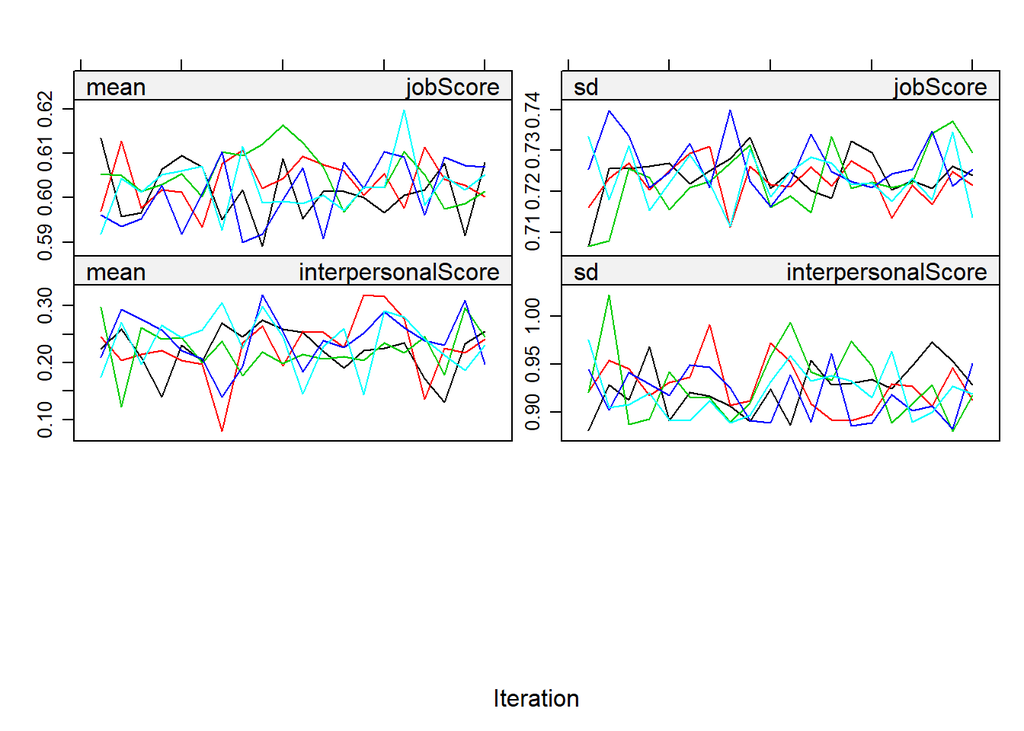

```r
miceMod = mice(week7, method = c(rep("", 12), "rf", "rf"),
               predictorMatrix = predictors, maxit = 20,
               print = FALSE, seed = 1001)

plot(miceMod)
```

Since we have some imputed data laying around, let’s see how things compare to the original data:

```r
summary(week7$jobScore)
```

```
##     Min.  1st Qu.   Median     Mean  3rd Qu.     Max.     NA's
## -1.85230 -1.05405 -0.06863 -0.10957  0.91657  1.23033      212
```

```r
complete(miceMod) %>%
  select(jobScore) %>%
  summary()
```

```
##     jobScore
##  Min.   :-1.8522974
##  1st Qu.:-0.9338053
##  Median : 0.1721467
##  Mean   : 0.0003397
##  3rd Qu.: 1.0385945
##  Max.   : 1.2303264
```

We certainly have some differences there!

All of this is fun, but let’s see the impact on our models:

```r
slimImpute = with(data = miceMod,
                  exp = lm(jobScore ~ salary))

summary(pool(slimImpute))
```

```
##                  estimate    std.error  statistic       df   p.value
## (Intercept)  8.951401e-03 7.133459e-02  0.1254847 1377.108 0.9001581
## salary      -1.197333e-07 8.638278e-07 -0.1386078 1377.785 0.8897803
```

Now, we can compare those to our standard model with missingness:

```r
broom::tidy(missingSlim)
```

```
##          term      estimate    std.error  statistic    p.value
## 1 (Intercept) -1.277960e-01 7.706132e-02 -1.6583678 0.09751129
## 2      salary  2.372039e-07 9.290111e-07  0.2553295 0.79851350
```

A sign flip on our salary coefficient!?!